# FeatureSelection

```python
from google.colab import drive
drive.mount('/content/drive')
```

```
Go to this URL in a browser: https://accounts.google.com/o/oauth2/auth?client_id=947318989803-6bn6qk8qdgf4n4g3pfee6491hc0brc4i.apps.googleusercontent.com&redirect_uri=urn%3aietf%3awg%3aoauth%3a2.0%3aoob&response_type=code&scope=email%20https%3a%2f%2fwww.googleapis.com%2fauth%2fdocs.test%20https%3a%2…

Enter your authorization code:
··········
```

```python
workdir='/content/drive/My Drive/CSML1030/'
datadir=workdir+'data/'
imagedir=workdir+'Images/'
```

## Feature Selection through Feature Importances :

Feature selection, the process of finding and selecting the most useful features in a dataset, is a crucial step of the machine learning pipeline. Unnecessary features decrease training speed, decrease model interpretability, and, most importantly, decrease generalization performance on the test set.

The techniques discussed in this kernel are below

1. Features with a high percentage of missing values
2. Collinear (highly correlated) features
3. Features with zero importance in a tree-based model

```python
import numpy as np # linear algebra
import pandas as pd # data processing, CSV file I/O (e.g. pd.read_csv)
from sklearn.impute import SimpleImputer
from  pprint import pprint
import seaborn as sns
import matplotlib.pyplot as plt
from sklearn.model_selection import train_test_split
from sklearn.model_selection import train_test_split
from sklearn.model_selection import KFold
from sklearn.metrics import roc_auc_score
from sklearn.preprocessing import LabelEncoder
import missingno as msno
pd.set_option('display.max_rows', 500)
pd.set_option('display.max_columns', 500)
pd.set_option('display.width', 1000)
%matplotlib inline
```

```python
import os
os.listdir(datadir)
```

```
['samplesubmission.csv',
 'solution_template.csv',
 'WiDS_Datathon_2020_Dictionary.csv',
 'unlabeled.csv',
 'training_v2.csv',
 'output_min.html']
```

```python
df = pd.read_csv(datadir+'training_v2.csv')
```

```python
df.head()
```

|  | encounter_id | patient_id | hospital_id | hospital_death | age | bmi | elective_surgery | ethnicity | gender | height | hospital_admit_source | icu_admit_source | icu_id | icu_stay_type | icu_type | pre_icu_los_days | readmission_status | weight | albumin_apache | apache_2_diagnosis | apache_3j_diagnosis | apache_post_operative | arf_apache | bilirubin_apache | bun_apache | creatinine_apache | fio2_apache | gcs_eyes_apache | gcs_motor_apache | … |
| --- | --- | --- | --- | --- | --- | --- | --- | --- | --- | --- | --- | --- | --- | --- | --- | --- | --- | --- | --- | --- | --- | --- | --- | --- | --- | --- | --- | --- | --- | --- |
| 0 | 66154 | 25312 | 118 | 0 | 68.0 | 22.73 | 0 | Caucasian | M | 180.3 | Floor | Floor | 92 | admit | CTICU | 0.541667 | 0 | 73.9 | 2.3 | 113.0 | 502.01 | 0 | 0.0 | 0.4 | 31.0 | 2.51 | NaN | 3.0 | 6.0 | … |
| 1 | 114252 | 59342 | 81 | 0 | 77.0 | 27.42 | 0 | Caucasian | F | 160.0 | Floor | Floor | 90 | admit | Med-Surg ICU | 0.927778 | 0 | 70.2 | NaN | 108.0 | 203.01 | 0 | 0.0 | NaN | 9.0 | 0.56 | 1.0 | 1.0 | 3.0 | … |
| 2 | 119783 | 50777 | 118 | 0 | 25.0 | 31.95 | 0 | Caucasian | F | 172.7 | Emergency Department | Accident & Emergency | 93 | admit | Med-Surg ICU | 0.000694 | 0 | 95.3 | NaN | 122.0 | 703.03 | 0 | 0.0 | NaN | NaN | NaN | NaN | 3.0 | 6.0 | … |
| 3 | 79267 | 46918 | 118 | 0 | 81.0 | 22.64 | 1 | Caucasian | F | 165.1 | Operating Room | Operating Room / Recovery | 92 | admit | CTICU | 0.000694 | 0 | 61.7 | NaN | 203.0 | 1206.03 | 1 | 0.0 | NaN | NaN | NaN | 0.6 | 4.0 | 6.0 | … |
| 4 | 92056 | 34377 | 33 | 0 | 19.0 | NaN | 0 | Caucasian | M | 188.0 | NaN | Accident & Emergency | 91 | admit | Med-Surg ICU | 0.073611 | 0 | NaN | NaN | 119.0 | 601.01 | 0 | 0.0 | NaN | NaN | NaN | NaN | NaN | NaN | … |

```python
#from pandas_profiling import ProfileReport
#profile = ProfileReport(df, minimal=True)
#profile.to_file(output_file=workdir+"output_min.html")
```

```python
numerics_cols=df.select_dtypes(include=np.number).columns.tolist()
categorical_cols=df.select_dtypes(exclude=np.number).columns.tolist()
categorical_cols
```

```
['ethnicity',
 'gender',
 'hospital_admit_source',
 'icu_admit_source',
 'icu_stay_type',
 'icu_type',
 'apache_3j_bodysystem',
 'apache_2_bodysystem']
```

```python
#Numerics_df= df[numerics_cols]
##Numerics_df    = df.select_dtypes(include=np.number)
#Numerics_df.shape
```

```python
#Numerics_df = Numerics_df.drop(['encounter_id','hospital_id'], axis=1)
#Numerics_df.head()
```

```python
# creating independent features X and dependant feature Y
y = df['hospital_death']
X = df[df.columns.difference(['hospital_death','encounter_id','hospital_id'])]
```

### Collinear (highly correlated) features

- Collinear features are features that are highly correlated with one another.
- These lead to decreased generalization performance on the test set due to high variance and less model interpretability.

```python
# Threshold for removing correlated variables
threshold = 0.9

# Absolute value correlation matrix
corr_matrix = df.corr().abs()
corr_matrix.head()
```

|  | encounter_id | patient_id | hospital_id | hospital_death | age | bmi | elective_surgery | height | icu_id | pre_icu_los_days | readmission_status | weight | albumin_apache | apache_2_diagnosis | apache_3j_diagnosis | apache_post_operative | arf_apache | bilirubin_apache | bun_apache | creatinine_apache | fio2_apache | gcs_eyes_apache | gcs_motor_apache | gcs_unable_apache | gcs_verbal_apache | glucose_apache | heart_rate_apache | hematocrit_apache | intubated_apache | … |
| --- | --- | --- | --- | --- | --- | --- | --- | --- | --- | --- | --- | --- | --- | --- | --- | --- | --- | --- | --- | --- | --- | --- | --- | --- | --- | --- | --- | --- | --- | --- |
| encounter_id | 1.000000 | 0.009575 | 0.004532 | 0.005243 | 0.003990 | 0.001068 | 0.002036 | 0.005400 | 0.000992 | 0.000570 | NaN | 0.004376 | 0.006262 | 0.000113 | 0.000651 | 0.001138 | 0.007920 | 0.002198 | 0.002619 | 0.005435 | 0.000824 | 0.003276 | 0.007664 | 0.002400 | 0.006516 | 0.002108 | 0.001718 | 0.001566 | 0.003172 | … |
| patient_id | 0.009575 | 1.000000 | 0.007075 | 0.004877 | 0.006343 | 0.001380 | 0.001387 | 0.002902 | 0.001770 | 0.004412 | NaN | 0.000275 | 0.001534 | 0.001539 | 0.004215 | 0.002260 | 0.003980 | 0.004292 | 0.002860 | 0.004134 | 0.003811 | 0.001551 | 0.002216 | 0.006673 | 0.000471 | 0.000270 | 0.004735 | 0.002944 | 0.001303 | … |
| hospital_id | 0.004532 | 0.007075 | 1.000000 | 0.001255 | 0.008673 | 0.012874 | 0.052123 | 0.027895 | 0.004526 | 0.001285 | NaN | 0.026314 | 0.011685 | 0.006806 | 0.031896 | 0.053985 | 0.000844 | 0.017921 | 0.014084 | 0.001126 | 0.014941 | 0.011727 | 0.020512 | 0.017576 | 0.002954 | 0.000057 | 0.007649 | 0.002436 | 0.027670 | … |
| hospital_death | 0.005243 | 0.004877 | 0.001255 | 1.000000 | 0.111017 | 0.031247 | 0.093574 | 0.019526 | 0.000994 | 0.063316 | NaN | 0.038362 | 0.193809 | 0.089862 | 0.090715 | 0.083674 | 0.027309 | 0.137464 | 0.181435 | 0.114699 | 0.212249 | 0.260373 | 0.282449 | 0.051774 | 0.241044 | 0.066430 | 0.107818 | 0.062600 | 0.173139 | … |
| age | 0.003990 | 0.006343 | 0.008673 | 0.111017 | 1.000000 | 0.087077 | 0.067320 | 0.109937 | 0.024257 | 0.049872 | NaN | 0.127252 | 0.116633 | 0.022914 | 0.056060 | 0.059246 | 0.001684 | 0.044981 | 0.237187 | 0.056178 | 0.037935 | 0.026363 | 0.025843 | 0.007754 | 0.017829 | 0.007043 | 0.149495 | 0.118853 | 0.015396 | … |

```python
# Upper triangle of correlations
upper = corr_matrix.where(np.triu(np.ones(corr_matrix.shape), k=1).astype(np.bool))
upper.head()
```

|  | encounter_id | patient_id | hospital_id | hospital_death | age | bmi | elective_surgery | height | icu_id | pre_icu_los_days | readmission_status | weight | albumin_apache | apache_2_diagnosis | apache_3j_diagnosis | apache_post_operative | arf_apache | bilirubin_apache | bun_apache | creatinine_apache | fio2_apache | gcs_eyes_apache | gcs_motor_apache | gcs_unable_apache | gcs_verbal_apache | glucose_apache | heart_rate_apache | hematocrit_apache | intubated_apache | … |
| --- | --- | --- | --- | --- | --- | --- | --- | --- | --- | --- | --- | --- | --- | --- | --- | --- | --- | --- | --- | --- | --- | --- | --- | --- | --- | --- | --- | --- | --- | --- |
| encounter_id | NaN | 0.009575 | 0.004532 | 0.005243 | 0.003990 | 0.001068 | 0.002036 | 0.005400 | 0.000992 | 0.000570 | NaN | 0.004376 | 0.006262 | 0.000113 | 0.000651 | 0.001138 | 0.007920 | 0.002198 | 0.002619 | 0.005435 | 0.000824 | 0.003276 | 0.007664 | 0.002400 | 0.006516 | 0.002108 | 0.001718 | 0.001566 | 0.003172 | … |
| patient_id | NaN | NaN | 0.007075 | 0.004877 | 0.006343 | 0.001380 | 0.001387 | 0.002902 | 0.001770 | 0.004412 | NaN | 0.000275 | 0.001534 | 0.001539 | 0.004215 | 0.002260 | 0.003980 | 0.004292 | 0.002860 | 0.004134 | 0.003811 | 0.001551 | 0.002216 | 0.006673 | 0.000471 | 0.000270 | 0.004735 | 0.002944 | 0.001303 | … |
| hospital_id | NaN | NaN | NaN | 0.001255 | 0.008673 | 0.012874 | 0.052123 | 0.027895 | 0.004526 | 0.001285 | NaN | 0.026314 | 0.011685 | 0.006806 | 0.031896 | 0.053985 | 0.000844 | 0.017921 | 0.014084 | 0.001126 | 0.014941 | 0.011727 | 0.020512 | 0.017576 | 0.002954 | 0.000057 | 0.007649 | 0.002436 | 0.027670 | … |
| hospital_death | NaN | NaN | NaN | NaN | 0.111017 | 0.031247 | 0.093574 | 0.019526 | 0.000994 | 0.063316 | NaN | 0.038362 | 0.193809 | 0.089862 | 0.090715 | 0.083674 | 0.027309 | 0.137464 | 0.181435 | 0.114699 | 0.212249 | 0.260373 | 0.282449 | 0.051774 | 0.241044 | 0.066430 | 0.107818 | 0.062600 | 0.173139 | … |
| age | NaN | NaN | NaN | NaN | NaN | 0.087077 | 0.067320 | 0.109937 | 0.024257 | 0.049872 | NaN | 0.127252 | 0.116633 | 0.022914 | 0.056060 | 0.059246 | 0.001684 | 0.044981 | 0.237187 | 0.056178 | 0.037935 | 0.026363 | 0.025843 | 0.007754 | 0.017829 | 0.007043 | 0.149495 | 0.118853 | 0.015396 | … |

```python
# Select columns with correlations above threshold
to_drop = [column for column in upper.columns if any(upper[column] > threshold)]
print('There are %d columns to remove.' % (len(to_drop)))
to_drop
```

```
There are 59 columns to remove.
```

```
['apache_post_operative',
 'paco2_for_ph_apache',
 'd1_diasbp_noninvasive_max',
 'd1_diasbp_noninvasive_min',
 'd1_mbp_noninvasive_max',
 'd1_mbp_noninvasive_min',
 'd1_sysbp_noninvasive_max',
 'd1_sysbp_noninvasive_min',
 'h1_diasbp_noninvasive_max',
 'h1_diasbp_noninvasive_min',
 'h1_mbp_noninvasive_max',
 'h1_mbp_noninvasive_min',
 'h1_sysbp_noninvasive_max',
 'h1_sysbp_noninvasive_min',
 'd1_albumin_max',
 'd1_albumin_min',
 'd1_bilirubin_max',
 'd1_bilirubin_min',
 'd1_bun_max',
 'd1_bun_min',
 'd1_creatinine_max',
 'd1_creatinine_min',
 'd1_glucose_max',
 'd1_hemaglobin_min',
 'd1_hematocrit_max',
 'd1_hematocrit_min',
 'd1_platelets_min',
 'd1_sodium_min',
 'd1_wbc_max',
 'd1_wbc_min',
 'h1_albumin_min',
 'h1_bilirubin_max',
 'h1_bilirubin_min',
 'h1_bun_max',
 'h1_bun_min',
 'h1_calcium_min',
 'h1_creatinine_max',
 'h1_creatinine_min',
 'h1_glucose_min',
 'h1_hco3_max',
 'h1_hco3_min',
 'h1_hemaglobin_max',
 'h1_hemaglobin_min',
 'h1_hematocrit_max',
 'h1_hematocrit_min',
 'h1_inr_max',
 'h1_inr_min',
 'h1_lactate_max',
 'h1_lactate_min',
 'h1_platelets_max',
 'h1_platelets_min',
 'h1_potassium_min',
 'h1_sodium_min',
 'h1_wbc_max',
 'h1_wbc_min',
 'h1_arterial_pco2_max',
 'h1_arterial_pco2_min',
 'h1_arterial_ph_min',
 'h1_pao2fio2ratio_min']
```

```python
#Drop the columns with high correlations
X = X.drop(columns = to_drop)
```

```python
#drop_colinear=df.drop(columns=to_drop)
#drop_colinear.to_csv(workdir+'data_processed/training_drop_colinear.csv',index=False)
```

### Features with a high percentage of missing values

- First we use missingno package to visualize the number of missing values as a bar chart

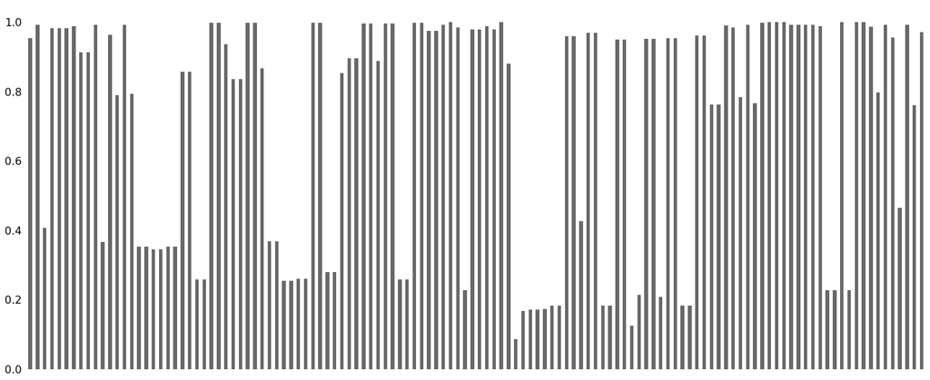

```python
# with first use missingno to  visualize the number of missing values as a bar chart
msno.bar(X)
```

```python
def get_percentage_missing(series):
    """ Calculates percentage of NaN values in DataFrame
    :param series: Pandas DataFrame object
    :return: float
    """
    num = series.isnull().sum()
    den = len(series)
    return round(num/den, 3)
```

```python
# Only include columns that contain any NaN values
X_with_any_null_values = X[X.columns[X.isnull().any()].tolist()]

percent_missing=get_percentage_missing(X_with_any_null_values)

percent_missing=percent_missing.sort_values(ascending = False)
# Show qty of each value in a Column
# df.astype(str).groupby(['col1']).sum()
pd.DataFrame({'column_name': X_with_any_null_values.columns,
                                 'percent_missing': percent_missing}).head()

#train_missing.sort_values('percent_missing', inplace=True)
```

|  | column_name | percent_missing |
| --- | --- | --- |
| h1_albumin_max | age | 0.914 |
| h1_pao2fio2ratio_max | aids | 0.874 |
| h1_arterial_ph_max | albumin_apache | 0.833 |
| h1_arterial_po2_max | apache_2_bodysystem | 0.828 |
| h1_arterial_po2_min | apache_2_diagnosis | 0.828 |

```python
train_missing = percent_missing.index[percent_missing > 0.75]
print('There are %d columns with more than 75%% missing values' % len(train_missing))
X = X.drop(columns = train_missing)
```

```
There are 18 columns with more than 75% missing values
```

```python
#drop_missing=drop_colinear.drop(columns=train_missing)
#drop_missing.to_csv(workdir+'data_processed/training_drop_missing.csv',index=False)
```

### Impute missing values

```python
drop_missing = pd.read_csv(workdir+'data_processed/training_drop_missing.csv')
numerics_cols=drop_missing.select_dtypes(include=np.number).columns.tolist()
drop_missing_NUM=drop_missing.select_dtypes(include=np.number)
```

```python
from fancyimpute import IterativeImputer
MICE_imputer = IterativeImputer()
drop_missing_NUM_MICE = drop_missing_NUM.copy(deep=True)
drop_missing_NUM_MICE.iloc[:, :] = MICE_imputer.fit_transform(drop_missing_NUM_MICE)
```

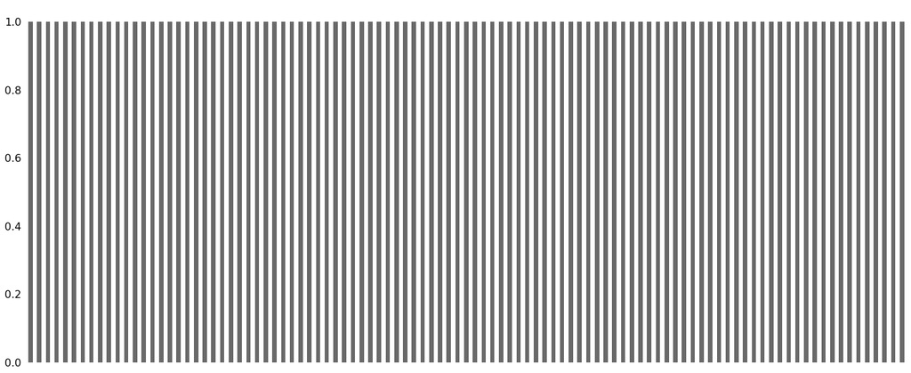

```python
msno.bar(drop_missing_NUM_MICE)
```

```python
drop_missing_NUM_MICE.to_csv(workdir+'data_processed/drop_missing_NUM_MIC.csv',index=False)
```

```python
from sklearn.impute import KNNImputer
knn_imputer = KNNImputer(n_neighbors=2)
drop_missing_NUM_knn = drop_missing_NUM.copy(deep=True)
drop_missing_NUM_knn.iloc[:, :] = knn_imputer.fit_transform(drop_missing_NUM_knn)
```

```python
#from fancyimpute import KNN
#knn_imputer = KNN()
#drop_missing_NUM_knn = drop_missing_NUM.copy(deep=True)
#drop_missing_NUM_knn.iloc[:, :] = knn_imputer.fit_transform(drop_missing_NUM_knn)
```

```python
drop_missing_NUM_knn.to_csv(workdir+'data_processed/drop_missing_NUM_knn.csv',index=False)
```

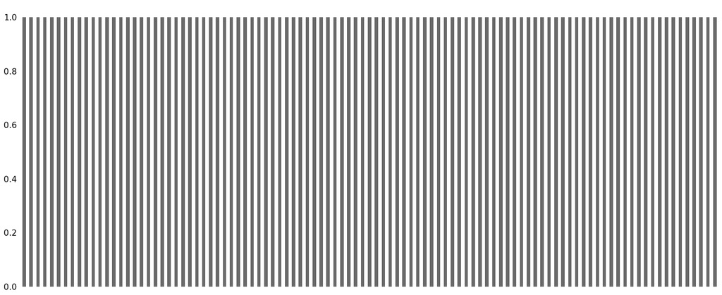

```python
msno.bar(drop_missing_NUM_knn)
```

#### Steps to impute categorical values

- Convert non-missing categorical columns to ordinal values
- Impute the missing values in the ordinal DataFrame
- Convert back from ordinal values to categorical values

```python
categorical_cols=drop_missing.select_dtypes(exclude=np.number).columns.tolist()
#drop_missing_CAT=drop_missing.select_dtypes(exclude=np.number)
drop_missing_CAT=drop_missing[categorical_cols]
```

```python
drop_missing_CAT.isnull().sum()
```

```
ethnicity                 1395
gender                      25
hospital_admit_source    21409
icu_admit_source           112
icu_stay_type                0
icu_type                     0
apache_3j_bodysystem      1662
apache_2_bodysystem       1662
dtype: int64
```

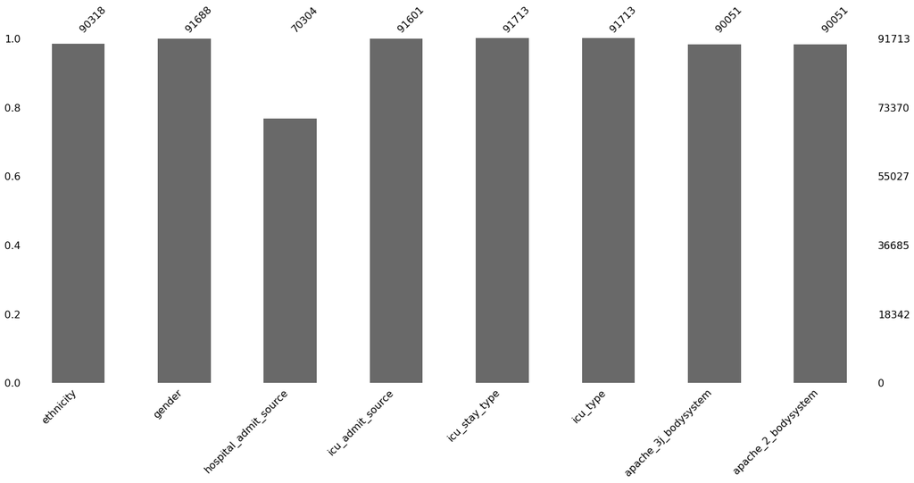

```python
msno.bar(drop_missing_CAT)
```

```python
#from sklearn.preprocessing import OrdinalEncoder


## Create Ordinal Encoder
#ethnicity_ord_enc= OrdinalEncoder()
##Select nonn-null values in ethnicity
#ethnicity = drop_missing_CAT['ethnicity']
#ethnicity_not_null = ethnicity[ethnicity.notnull()]
#reshaped_vals = ethnicity_not_null.values.reshape(-1,1)
##Encode the non-null values of ethnicity
#encoded_vals = ethnicity_ord_enc.fit_transform(reshaped_vals)
##Replace the ethnicity column with ordinal values
#drop_missing_CAT.loc[ethnicity.notnull(),'ethnicity']=np.squeeze(encoded_vals)
```

```python
drop_missing_CAT_ordinal = drop_missing_CAT.copy(deep=True)
# Create dictionary for Ordinal encoders
ordinal_enc_dict = {}
  # Loop over columns to encode
for col_name in drop_missing_CAT:
  # Create ordinal encoder for the column
  ordinal_enc_dict[col_name] = OrdinalEncoder()

  # Select the nin-null values in the column
  col = drop_missing_CAT[col_name]
  col_not_null = col[col.notnull()]
  reshaped_vals = col_not_null.values.reshape(-1, 1)

  # Encode the non-null values of the column
  encoded_vals = ordinal_enc_dict[col_name].fit_transform(reshaped_vals)

  ##Replace the column with ordinal values

  drop_missing_CAT_ordinal.loc[col.notnull(),col_name]  =np.squeeze(encoded_vals)
  print('+Encode: {} '.format(col_name))
```

```
+Encode: ethnicity
+Encode: gender
+Encode: hospital_admit_source
+Encode: icu_admit_source
+Encode: icu_stay_type
+Encode: icu_type
+Encode: apache_3j_bodysystem
+Encode: apache_2_bodysystem
```

```python
ordinal_enc_dict
```

```
{'apache_2_bodysystem': OrdinalEncoder(categories='auto', dtype=<class 'numpy.float64'>),
 'apache_3j_bodysystem': OrdinalEncoder(categories='auto', dtype=<class 'numpy.float64'>),
 'ethnicity': OrdinalEncoder(categories='auto', dtype=<class 'numpy.float64'>),
 'gender': OrdinalEncoder(categories='auto', dtype=<class 'numpy.float64'>),
 'hospital_admit_source': OrdinalEncoder(categories='auto', dtype=<class 'numpy.float64'>),
 'icu_admit_source': OrdinalEncoder(categories='auto', dtype=<class 'numpy.float64'>),
 'icu_stay_type': OrdinalEncoder(categories='auto', dtype=<class 'numpy.float64'>),
 'icu_type': OrdinalEncoder(categories='auto', dtype=<class 'numpy.float64'>)}
```

```python
drop_missing_CAT_MICE_imputed = drop_missing_CAT_ordinal.copy(deep=True) # Create MICE imputer
MICE_imputer = IterativeImputer()
drop_missing_CAT_MICE_imputed.iloc[:, :] = np.round(MICE_imputer.fit_transform(drop_missing_CAT_MICE_imputed))

for col in drop_missing_CAT_MICE_imputed:
  reshaped_col = drop_missing_CAT_MICE_imputed[col].values.reshape(-1, 1)
  drop_missing_CAT_MICE_imputed[col] = ordinal_enc_dict[col].inverse_transform(reshaped_col)
```

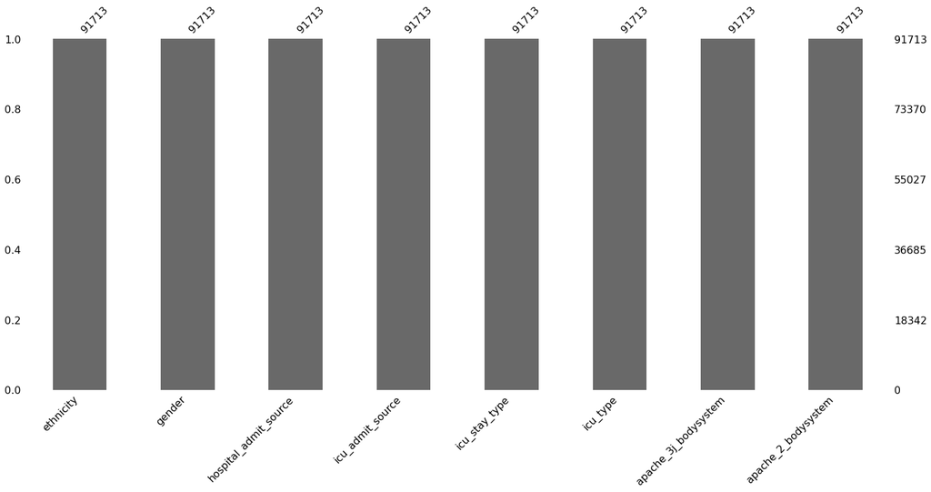

```python
msno.bar(drop_missing_CAT_MICE_imputed)
```

```python
drop_missing_CAT_MICE_imputed.head()
```

|  | ethnicity | gender | hospital_admit_source | icu_admit_source | icu_stay_type | icu_type | apache_3j_bodysystem | apache_2_bodysystem |
| --- | --- | --- | --- | --- | --- | --- | --- | --- |
| 0 | Caucasian | M | Floor | Floor | admit | CTICU | Sepsis | Cardiovascular |
| 1 | Caucasian | F | Floor | Floor | admit | Med-Surg ICU | Respiratory | Respiratory |
| 2 | Caucasian | F | Emergency Department | Accident & Emergency | admit | Med-Surg ICU | Metabolic | Metabolic |
| 3 | Caucasian | F | Operating Room | Operating Room / Recovery | admit | CTICU | Cardiovascular | Cardiovascular |
| 4 | Caucasian | M | Emergency Department | Accident & Emergency | admit | Med-Surg ICU | Trauma | Trauma |

```python
drop_missing_CAT_MICE_imputed.to_csv(workdir+'data_processed/drop_missing_CAT_MICE_imputed.csv',index=False)
```

```python
from sklearn.impute import KNNImputer
KNN_imputer = KNNImputer(n_neighbors=2)

drop_missing_CAT_KNN_imputed = drop_missing_CAT_ordinal.copy(deep=True) # Create MICE imputer
drop_missing_CAT_KNN_imputed.iloc[:, :] = np.round(KNN_imputer.fit_transform(drop_missing_CAT_KNN_imputed))
for col in drop_missing_CAT_KNN_imputed:
  reshaped_col = drop_missing_CAT_KNN_imputed[col].values.reshape(-1, 1)
  drop_missing_CAT_KNN_imputed[col] = ordinal_enc_dict[col].inverse_transform(reshaped_col)
```

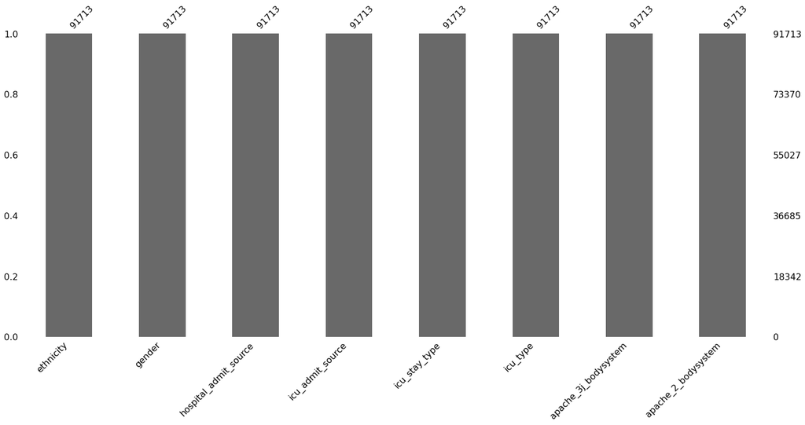

```python
msno.bar(drop_missing_CAT_KNN_imputed)
```

```python
drop_missing_CAT_KNN_imputed.to_csv(workdir+'data_processed/drop_missing_CAT_KNN_imputed.csv',index=False)
```

```python
import fancyimpute
KNN_imputer = fancyimpute.KNN(k=2)
```

```python
#from fancyimpute import KNN
#ifancyimpute
#KNN_imputer = KNN(k=3)

drop_missing_CAT_KNN2_imputed = drop_missing_CAT_ordinal.copy(deep=True) # Create MICE imputer
drop_missing_CAT_KNN2_imputed.iloc[:, :] = np.round(KNN_imputer.fit_transform(drop_missing_CAT_KNN2_imputed))
for col in drop_missing_CAT_KNN2_imputed:
  reshaped_col = drop_missing_CAT_KNN2_imputed[col].values.reshape(-1, 1)
  drop_missing_CAT_KNN2_imputed[col] = ordinal_enc_dict[col].inverse_transform(reshaped_col)
```

```python
drop_missing_CAT_KNN2_imputed.to_csv(workdir+'data_processed/drop_missing_CAT_KNN2_imputed.csv',index=False)
```

```python
drop_missing_NUM_MICE=pd.read_csv(workdir+'data_processed/drop_missing_NUM_MIC.csv')
drop_missing_NUM_knn=pd.read_csv(workdir+'data_processed/drop_missing_NUM_knn.csv')
drop_missing_CAT_MICE_imputed=pd.read_csv(workdir+'data_processed/drop_missing_CAT_MICE_imputed.csv')
drop_missing_CAT_KNN_imputed=pd.read_csv(workdir+'data_processed/drop_missing_CAT_KNN_imputed.csv')
```

```python
drop_missing_NUM_MICE.head()
```

|  | encounter_id | patient_id | hospital_id | hospital_death | age | bmi | elective_surgery | height | icu_id | pre_icu_los_days | readmission_status | weight | albumin_apache | apache_2_diagnosis | apache_3j_diagnosis | arf_apache | bilirubin_apache | bun_apache | creatinine_apache | gcs_eyes_apache | gcs_motor_apache | gcs_unable_apache | gcs_verbal_apache | glucose_apache | heart_rate_apache | hematocrit_apache | intubated_apache | map_apache | resprate_apache | … |
| --- | --- | --- | --- | --- | --- | --- | --- | --- | --- | --- | --- | --- | --- | --- | --- | --- | --- | --- | --- | --- | --- | --- | --- | --- | --- | --- | --- | --- | --- | --- |
| 0 | 66154.0 | 25312.0 | 118.0 | 0.0 | 68.0 | 22.73000 | 0.0 | 180.3 | 92.0 | 0.541667 | 0.0 | 73.900000 | 2.300000 | 113.0 | 502.01 | 0.0 | 0.400000 | 31.000000 | 2.510000 | 3.000000 | 6.000000 | 0.000000 | 4.00000 | 168.000000 | 118.0 | 27.400000 | 0.0 | 40.0 | 36.0 | … |
| 1 | 114252.0 | 59342.0 | 81.0 | 0.0 | 77.0 | 27.42000 | 0.0 | 160.0 | 90.0 | 0.927778 | 0.0 | 70.200000 | 1.957237 | 108.0 | 203.01 | 0.0 | -0.800192 | 9.000000 | 0.560000 | 1.000000 | 3.000000 | 0.000000 | 1.00000 | 145.000000 | 120.0 | 36.900000 | 0.0 | 46.0 | 33.0 | … |
| 2 | 119783.0 | 50777.0 | 118.0 | 0.0 | 25.0 | 31.95000 | 0.0 | 172.7 | 93.0 | 0.000694 | 0.0 | 95.300000 | 3.139296 | 122.0 | 703.03 | 0.0 | 1.039263 | 16.284140 | 1.283226 | 3.000000 | 6.000000 | 0.000000 | 5.00000 | 150.549279 | 102.0 | 35.918734 | 0.0 | 68.0 | 37.0 | … |
| 3 | 79267.0 | 46918.0 | 118.0 | 0.0 | 81.0 | 22.64000 | 1.0 | 165.1 | 92.0 | 0.000694 | 0.0 | 61.700000 | 2.712390 | 203.0 | 1206.03 | 0.0 | 0.719184 | 24.086757 | 1.405235 | 4.000000 | 6.000000 | 0.000000 | 5.00000 | 185.000000 | 114.0 | 25.900000 | 1.0 | 60.0 | 4.0 | … |
| 4 | 92056.0 | 34377.0 | 33.0 | 0.0 | 19.0 | 25.25983 | 0.0 | 188.0 | 91.0 | 0.073611 | 0.0 | 91.876315 | 3.261042 | 119.0 | 601.01 | 0.0 | 1.009392 | 13.926295 | 1.201185 | 3.589562 | 5.641357 | 0.015057 | 4.47675 | 140.151329 | 60.0 | 36.951601 | 0.0 | 103.0 | 16.0 | … |

```python
 drop_missing_MICE=pd.concat([drop_missing_NUM_MICE, drop_missing_CAT_MICE_imputed], axis=1)
 drop_missing_MICE.to_csv(workdir+'data_processed/drop_missing_MICE_imputed.csv',index=False)
```

```python
 drop_missing_KNN=pd.concat([drop_missing_NUM_knn, drop_missing_CAT_KNN_imputed], axis=1)
 drop_missing_KNN.to_csv(workdir+'data_processed/drop_missing_KNN_imputed.csv',index=False)
```

### Features with zero importance in a tree-based model

We will use non-deterministic function to find features that have zero importance

```python
#training_drop_missing=pd.read_csv(workdir+'data_processed/training_drop_missing.csv')
training_drop_missing=pd.read_csv(workdir+'data_processed/drop_missing_MICE_imputed.csv')
y = training_drop_missing['hospital_death']
X = training_drop_missing[training_drop_missing.columns.difference(['hospital_death','encounter_id','hospital_id','patient_id'])]
```

```python
X.select_dtypes(exclude=np.number).columns.tolist()
```

```
['apache_2_bodysystem',
 'apache_3j_bodysystem',
 'ethnicity',
 'gender',
 'hospital_admit_source',
 'icu_admit_source',
 'icu_stay_type',
 'icu_type']
```

```python
#X['ethnicity']=X['ethnicity'].astype(object, axis=0)
#X['gender']=X['gender'].astype(object, axis=0)
#X['hospital_admit_source']=X['hospital_admit_source'].astype(object, axis=0)
#X['icu_admit_source']=X['icu_admit_source'].astype(object, axis=0)
#X['icu_stay_type']=X['icu_stay_type'].astype(object, axis=0)
#X['icu_type']=X['icu_type'].astype(object, axis=0)
#X['apache_3j_bodysystem']=X['apache_3j_bodysystem'].astype(object, axis=0)
#X['apache_2_bodysystem']=X['apache_2_bodysystem'].astype(object, axis=0)
```

```python
#import lightgbm as lgb
#Convert categorical variable into dummy/indicator variables.
X_dummies = pd.get_dummies(X)
```

#### Hotencode

```python
from sklearn.datasets import fetch_openml
from sklearn.experimental import enable_iterative_imputer
from sklearn.impute import  SimpleImputer, MissingIndicator, IterativeImputer
from sklearn.impute import KNNImputer
#from sklearn.model_selection import train_test_split
from sklearn.pipeline import Pipeline
from sklearn.preprocessing import OneHotEncoder
from sklearn.inspection import permutation_importance
from sklearn.compose import ColumnTransformer
```

```python
#Iterative_Imputer = IterativeImputer(max_iter=100, random_state=0)
```

```python
#X_Iterative_Imputed= Iterative_Imputer.fit_transform(X_dummies)
```

```python
#import pickle as pkl
#with open(workdir+'X_Iterative_Imputed.pkl','wb') as f: pickle.dump(X_Iterative_Imputed, f)

#with open('filename','rb') as f: arrayname1 = pickle.load(f)
```

#### Gradient boosting machine (GBM) learning model.

```python
import lightgbm as lgb
```

```python
# Initialize an empty array to hold feature importances
feature_importances = np.zeros(X_dummies.shape[1])

# Create the model with several hyperparameters
model = lgb.LGBMClassifier(objective='binary', boosting_type = 'goss', n_estimators = 10000, class_weight = 'balanced')
```

```python
for i in range(2):

    # Split into training and validation set
    train_features, valid_features, train_y, valid_y = train_test_split(X_dummies, y, test_size = 0.25, random_state = i, stratify=y)

    # Train using early stopping
    model.fit(train_features, train_y, early_stopping_rounds=100, eval_set = [(valid_features, valid_y)],eval_metric = 'auc', verbose = 200)

    # Record the feature importances
    feature_importances += model.feature_importances_
```

```
Training until validation scores don't improve for 100 rounds.
[200]	valid_0's auc: 0.93503	valid_0's binary_logloss: 0.241354
[400]	valid_0's auc: 0.936587	valid_0's binary_logloss: 0.198584
[600]	valid_0's auc: 0.937128	valid_0's binary_logloss: 0.180822
[800]	valid_0's auc: 0.938272	valid_0's binary_logloss: 0.172939
[1000]	valid_0's auc: 0.93898	valid_0's binary_logloss: 0.171533
Early stopping, best iteration is:
[1074]	valid_0's auc: 0.939531	valid_0's binary_logloss: 0.171374
Training until validation scores don't improve for 100 rounds.
[200]	valid_0's auc: 0.936915	valid_0's binary_logloss: 0.238714
Early stopping, best iteration is:
[218]	valid_0's auc: 0.937333	valid_0's binary_logloss: 0.232613
```

```python
# Make sure to average feature importances!
feature_importances = feature_importances / 2
feature_importances = pd.DataFrame({'feature': list(X_dummies.columns), 'importance': feature_importances}).sort_values('importance', ascending = False)
feature_importances.head()
```

|  | feature | importance |
| --- | --- | --- |
| 34 | d1_lactate_min | 508.0 |
| 33 | d1_lactate_max | 455.0 |
| 94 | urineoutput_apache | 450.0 |
| 8 | bilirubin_apache | 416.5 |
| 22 | d1_diasbp_invasive_min | 378.5 |

```python
feature_importances.to_csv(workdir+'data_processed/feature_importances_GBM.csv',index=False)
```

```python
# Find the features with zero importance
zero_features = list(feature_importances[feature_importances['importance'] == 0.0]['feature'])
print('There are %d features with 0.0 importance' % len(zero_features))
feature_importances.tail()
# Drop features with zero importance
X_dummies = X_dummies.drop(columns = zero_features)
```

```
There are 10 features with 0.0 importance
```

```python
#X_dummies.to_csv(workdir+'data_processed/GBM_drop_importance.csv',index=False)
```

```python
zero_features
```

```
['hospital_admit_source_Other',
 'readmission_status',
 'apache_2_bodysystem_Undefined Diagnoses',
 'apache_3j_bodysystem_Hematological',
 'hospital_admit_source_Chest Pain Center',
 'apache_3j_bodysystem_Gynecological',
 'apache_3j_bodysystem_Respiratory',
 'hospital_admit_source_ICU to SDU',
 'hospital_admit_source_Observation',
 'apache_3j_bodysystem_Trauma']
```

```python
def plot_feature_importances(df, threshold = 0.95):
    """
    Plots 15 most important features and the cumulative importance of features.
    Prints the number of features needed to reach threshold cumulative importance.

    Parameters
    --------
    df : dataframe
        Dataframe of feature importances. Columns must be feature and importance
    threshold : float, default = 0.9
        Threshold for prining information about cumulative importances

    Return
    --------
    df : dataframe
        Dataframe ordered by feature importances with a normalized column (sums to 1)
        and a cumulative importance column

    """

    plt.rcParams['font.size'] = 18

    # Sort features according to importance
    df = df.sort_values('importance', ascending = False).reset_index()

    # Normalize the feature importances to add up to one
    df['importance_normalized'] = df['importance'] / df['importance'].sum()
    df['cumulative_importance'] = np.cumsum(df['importance_normalized'])

    # Make a horizontal bar chart of feature importances
    f,ax=plt.subplots(1,2,figsize=(30,12))
    #plt.figure(figsize = (10, 6))
    #ax = plt.subplot()

    # Need to reverse the index to plot most important on top
    ax[0].barh(list(reversed(list(df.index[:15]))),
            df['importance_normalized'].head(15),
            align = 'center', edgecolor = 'k')

    # Set the yticks and labels
    ax[0].set_yticks(list(reversed(list(df.index[:15]))))
    ax[0].set_yticklabels(df['feature'].head(15))



    # Plot labeling
    ax[0].set_title('Feature Importances')
    ax[0].set_ylabel('Normalized Importance')

    #plt.xlabel('Normalized Importance'); plt.title('Feature Importances')
    #plt.show()


    # Cumulative importance plot
    #plt.figure(figsize = (8, 10))
    plt.plot(list(range(len(df))), df['cumulative_importance'], 'r-')
    #plt.xlabel('Number of Features'); plt.ylabel('Cumulative Importance');
    ax[1].set_title('Cumulative Feature Importance')
    ax[1].set_ylabel('Cumulative Importance')
    ax[1].set_xlabel('Number of Features')
    #plt.title('Cumulative Feature Importance');
    plt.show();
    f.savefig(imagedir+'Feature_Importances.png', dpi=300)
    importance_index = np.min(np.where(df['cumulative_importance'] > threshold))
    print('%d features required for %0.2f of cumulative importance' % (importance_index + 1, threshold))

    return df
```

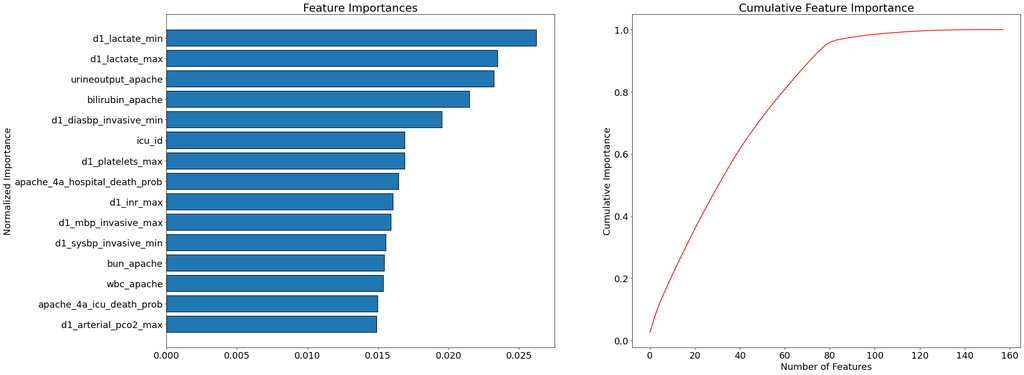

```
80 features required for 0.95 of cumulative importance
```

```python
norm_feature_importances = plot_feature_importances(feature_importances)
```

We can keep only the features needed for 95% importance. This step seems to me to have the greatest chance of harming the model's learning ability, so rather than changing the original dataset, we will make smaller copies. Then, we can test both versions of the data to see if the extra feature removal step is worthwhile.

```python
# Threshold for cumulative importance
threshold = 0.95
# Extract the features to keep
features_to_keep = list(norm_feature_importances[norm_feature_importances['cumulative_importance'] < threshold]['feature'])

# Create new datasets with smaller features
train_small = train[features_to_keep]
test_small= unlabeled[features_to_keep]
```

```python
train_small['TARGET'] = drop_missing_MICE_imputed['hospital_death']
train_small['encounter_id'] = drop_missing_MICE_imputed['encounter_id']
test_small['encounter_id'] = unlabeled['encounter_id']

#X_dummies.to_csv(workdir+'data_processed/GBM_drop_importance.csv',index=False)
train_small.to_csv(workdir+'data_processed/GBM_train_small.csv', index = False)
test_small.to_csv(workdir+'data_processed/GBM_test_small.csv', index = False)
```

## Test New Featuresets

```python
unlabeled=pd.read_csv(datadir+'unlabeled.csv')
unlabeled.head()
```

|  | encounter_id | patient_id | hospital_id | hospital_death | age | bmi | elective_surgery | ethnicity | gender | height | hospital_admit_source | icu_admit_source | icu_id | icu_stay_type | icu_type | pre_icu_los_days | readmission_status | weight | albumin_apache | apache_2_diagnosis | apache_3j_diagnosis | apache_post_operative | arf_apache | bilirubin_apache | bun_apache | creatinine_apache | fio2_apache | gcs_eyes_apache | gcs_motor_apache | … |
| --- | --- | --- | --- | --- | --- | --- | --- | --- | --- | --- | --- | --- | --- | --- | --- | --- | --- | --- | --- | --- | --- | --- | --- | --- | --- | --- | --- | --- | --- | --- |
| 0 | 2 | 127112 | 7 | NaN | 56.0 | 21.102439 | 0 | Caucasian | M | 180.3 | Emergency Department | Accident & Emergency | 1105 | admit | Neuro ICU | 0.104167 | 0 | 68.6 | 3.7 | 301.0 | 405.01 | 0 | 0.0 | NaN | 19.0 | 0.67 | NaN | 2.0 | 5.0 | … |
| 1 | 5 | 130737 | 178 | NaN | NaN | 19.500595 | 1 | Caucasian | F | 145.0 | Operating Room | Operating Room / Recovery | 1043 | admit | Med-Surg ICU | 0.230556 | 0 | 41.0 | NaN | 217.0 | 1502.02 | 1 | 0.0 | NaN | NaN | NaN | NaN | 4.0 | 6.0 | … |
| 2 | 7 | 101458 | 86 | NaN | 66.0 | 32.518596 | 1 | African American | M | 170.2 | Operating Room | Operating Room / Recovery | 1035 | admit | CCU-CTICU | 0.140972 | 0 | 94.2 | NaN | 302.0 | 1208.06 | 1 | 0.0 | NaN | 22.0 | 1.84 | NaN | 2.0 | 5.0 | … |
| 3 | 8 | 48067 | 163 | NaN | 64.0 | 20.798520 | 0 | Caucasian | M | 182.8 | Operating Room | Operating Room / Recovery | 1078 | admit | Med-Surg ICU | 0.002083 | 0 | 69.5 | 1.9 | 303.0 | 211.03 | 0 | 0.0 | 0.8 | 24.0 | 0.75 | 0.7 | 4.0 | 6.0 | … |
| 4 | 10 | 25865 | 59 | NaN | 56.0 | NaN | 0 | Caucasian | M | NaN | Emergency Department | Accident & Emergency | 1012 | admit | Neuro ICU | 0.004861 | 0 | 66.4 | NaN | 217.0 | 1501.01 | 1 | 0.0 | NaN | 11.0 | 0.52 | NaN | 1.0 | 4.0 | … |

```python
samplesubmission=pd.read_csv(datadir+'samplesubmission.csv')
```

```python
samplesubmission.head()
```

|  | encounter_id | hospital_death |
| --- | --- | --- |
| 0 | 2 | 0.500 |
| 1 | 5 | 0.200 |
| 2 | 7 | 0.001 |

```python
drop_missing_MICE_imputed=pd.read_csv(workdir+'data_processed/drop_missing_KNN_imputed.csv')
```

```python
 #Imports used by model
from sklearn.model_selection import KFold
from sklearn.metrics import roc_auc_score
from sklearn.preprocessing import LabelEncoder

import gc
```

```python
def model(features, test_features, encoding = 'ohe', n_folds = 20,):

    """Train and test a light gradient boosting model using
    cross validation.

    Parameters
    --------
        features (pd.DataFrame):
            dataframe of training features to use
            for training a model. Must include the TARGET column.
        test_features (pd.DataFrame):
            dataframe of testing features to use
            for making predictions with the model.
        encoding (str, default = 'ohe'):
            method for encoding categorical variables. Either 'ohe' for one-hot encoding or 'le' for integer label encoding
            n_folds (int, default = 5): number of folds to use for cross validation

    Return
    --------
        submission (pd.DataFrame):
            dataframe with `encounter_id` and `TARGET` probabilities
            predicted by the model.
        feature_importances (pd.DataFrame):
            dataframe with the feature importances from the model.
        valid_metrics (pd.DataFrame):
            dataframe with training and validation metrics (ROC AUC) for each fold and overall.

    """

    # Extract the ids
    train_ids = features['encounter_id']
    test_ids = test_features['encounter_id']

    # Extract the labels for training
    labels = features['TARGET']
    # Remove the ids and target
    features = features.drop(columns = ['encounter_id', 'TARGET'])
    test_features = test_features.drop(columns = ['encounter_id',])


    ## One Hot Encoding
    if encoding == 'ohe':
      features = pd.get_dummies(features)
      test_features = pd.get_dummies(test_features)

        # Align the dataframes by the columns
      features, test_features = features.align(test_features, join = 'inner', axis = 1)

        # No categorical indices to record
      cat_indices = 'auto'

    # Integer label encoding
    elif encoding == 'le':

        # Create a label encoder
        label_encoder = LabelEncoder()

        # List for storing categorical indices
        cat_indices = []

        # Iterate through each column
        for i, col in enumerate(features):
            if features[col].dtype == 'object':
                # Map the categorical features to integers
                features[col] = label_encoder.fit_transform(np.array(features[col].astype(str)).reshape((-1,)))
                test_features[col] = label_encoder.transform(np.array(test_features[col].astype(str)).reshape((-1,)))

                # Record the categorical indices
                cat_indices.append(i)

    # Catch error if label encoding scheme is not valid
    else:
        raise ValueError("Encoding must be either 'ohe' or 'le'")

    print('Training Data Shape: ', features.shape)
    print('Testing Data Shape: ', test_features.shape)

    # Extract feature names
    feature_names = list(features.columns)
    print('Extract feature names')
    # Convert to np arrays
    features = np.array(features)
    test_features = np.array(test_features)
    print('Convert feature names to np arrays')
    # Create the kfold object
    k_fold = KFold(n_splits = n_folds, shuffle = False, random_state = 50)

    # Empty array for feature importances
    feature_importance_values = np.zeros(len(feature_names))

    # Empty array for test predictions
    test_predictions = np.zeros(test_features.shape[0])

    # Empty array for out of fold validation predictions
    out_of_fold = np.zeros(features.shape[0])

    # Lists for recording validation and training scores
    valid_scores = []
    train_scores = []

    # Iterate through each fold
    for train_indices, valid_indices in k_fold.split(features):

        # Training data for the fold
        train_features, train_labels = features[train_indices], labels[train_indices]
        # Validation data for the fold
        valid_features, valid_labels = features[valid_indices], labels[valid_indices]

        # Create the model
        model = lgb.LGBMClassifier(n_estimators=10000, objective = 'binary', boosting_type='goss',
                                   class_weight = 'balanced', learning_rate = 0.05,
                                   reg_alpha = 0.1, reg_lambda = 0.1, n_jobs = -1, random_state = 50)

        # Train the model
        model.fit(train_features, train_labels, eval_metric = 'auc',
                  eval_set = [(valid_features, valid_labels), (train_features, train_labels)],
                  eval_names = ['valid', 'train'], categorical_feature = cat_indices,
                  early_stopping_rounds = 100, verbose = 200)

        # Record the best iteration
        best_iteration = model.best_iteration_

        # Record the feature importances
        feature_importance_values += model.feature_importances_ / k_fold.n_splits

        # Make predictions
        test_predictions += model.predict_proba(test_features, num_iteration = best_iteration)[:, 1] / k_fold.n_splits

        # Record the out of fold predictions
        out_of_fold[valid_indices] = model.predict_proba(valid_features, num_iteration = best_iteration)[:, 1]

        # Record the best score
        valid_score = model.best_score_['valid']['auc']
        train_score = model.best_score_['train']['auc']

        valid_scores.append(valid_score)
        train_scores.append(train_score)

        # Clean up memory
        gc.enable()
        del model, train_features, valid_features
        gc.collect()

    # Make the submission dataframe
    submission = pd.DataFrame({'encounter_id': test_ids, 'TARGET': test_predictions})

    # Make the feature importance dataframe
    feature_importances = pd.DataFrame({'feature': feature_names, 'importance': feature_importance_values})

    # Overall validation score
    valid_auc = roc_auc_score(labels, out_of_fold)

    # Add the overall scores to the metrics
    valid_scores.append(valid_auc)
    train_scores.append(np.mean(train_scores))

    # Needed for creating dataframe of validation scores
    fold_names = list(range(n_folds))
    fold_names.append('overall')

    # Dataframe of validation scores
    metrics = pd.DataFrame({'fold': fold_names,
                            'train': train_scores,
                            'valid': valid_scores})

    return submission, feature_importances, metrics
```